[figure not shown]

# Categorical Plots - Statistical Estimation within Categories

Often we have **categorical** data, meaning the data is in distinct groupings, such as Countries or Companies. There is no country value "between" USA and France and there is no company value "between" Google and Apple, unlike continuous data where we know values can exist between data points, such as age or price.

To begin with categorical plots, we'll focus on statistical estimation within categories. Basically this means we will visually report back some statistic (such as mean or count) in a plot. We already know how to get this data with pandas, but often its easier to understand the data if we plot this.

## Imports

```python
import numpy as np
import pandas as pd
import matplotlib.pyplot as plt
import seaborn as sns
```

## The Data

```python
df = pd.read_csv("dm_office_sales.csv")
```

```python
df.head()
```

|  | division | level of education | training level | work experience | salary | sales |
| --- | --- | --- | --- | --- | --- | --- |
| 0 | printers | some college | 2 | 6 | 91684 | 372302 |
| 1 | printers | associate's degree | 2 | 10 | 119679 | 495660 |
| 2 | peripherals | high school | 0 | 9 | 82045 | 320453 |
| 3 | office supplies | associate's degree | 2 | 5 | 92949 | 377148 |
| 4 | office supplies | high school | 1 | 5 | 71280 | 312802 |

## Countplot()

A simple plot, it merely shows the total count of rows per category.

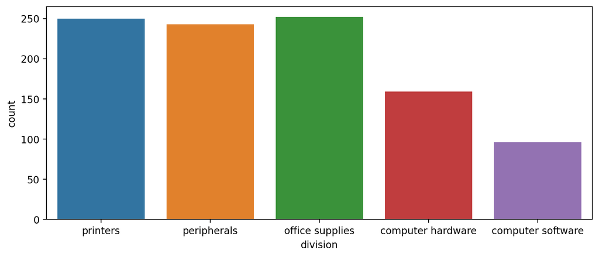

```python
plt.figure(figsize=(10,4),dpi=200)
sns.countplot(x='division',data=df)
```

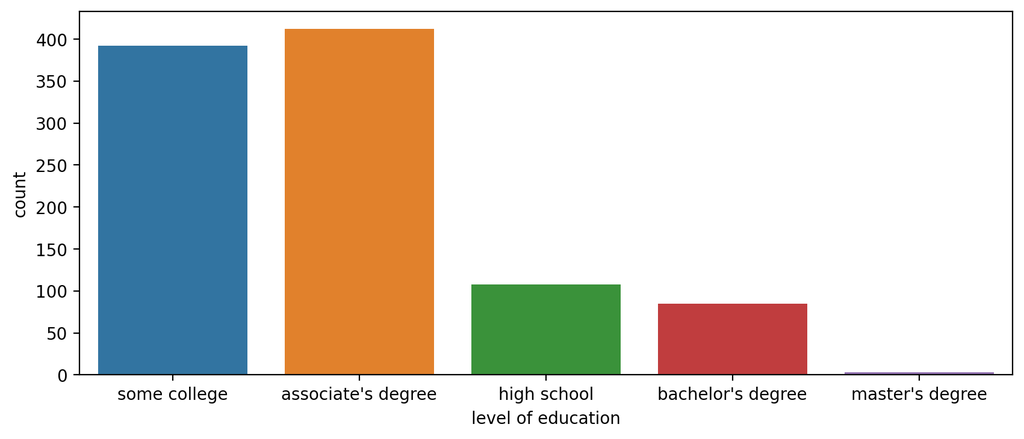

```python
plt.figure(figsize=(10,4),dpi=200)
sns.countplot(x='level of education',data=df)
```

### Breakdown within another category with 'hue'

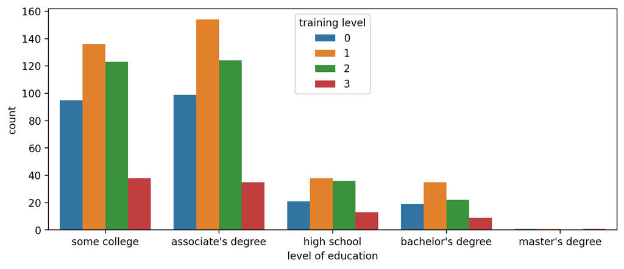

```python
plt.figure(figsize=(10,4),dpi=200)
sns.countplot(x='level of education',data=df,hue='training level')
```

**NOTE: You can always edit the palette to your liking to any matplotlib [colormap](https://matplotlib.org/3.1.1/gallery/color/colormap_reference.html)**

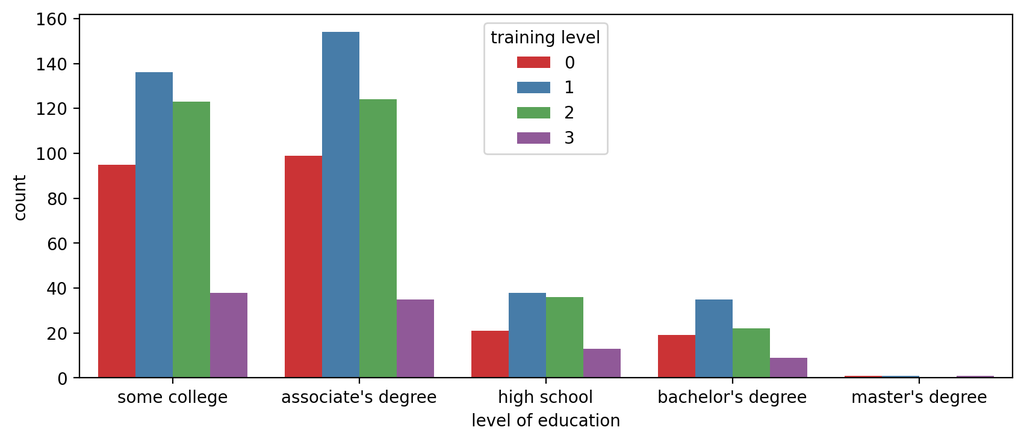

```python
plt.figure(figsize=(10,4),dpi=200)
sns.countplot(x='level of education',data=df,hue='training level',palette='Set1')
```

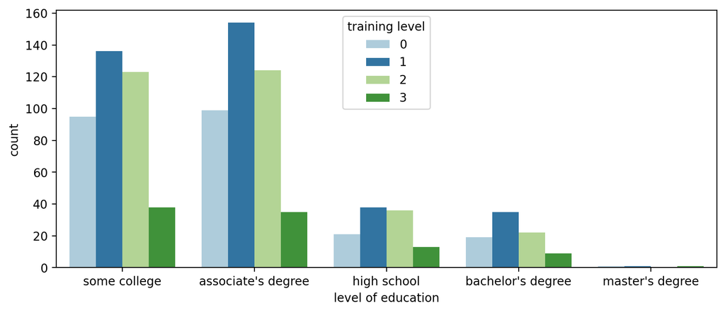

```python
plt.figure(figsize=(10,4),dpi=200)
# Paired would be a good choice if there was a distinct jump from 0 and 1 to 2 and 3
sns.countplot(x='level of education',data=df,hue='training level',palette='Paired')
```

# barplot()

So far we've seen the y axis default to a count (similar to a .groupby(x_axis).count() call in pandas). We can expand our visualizations by specifying a specific continuous feature for the y-axis. Keep in mind, you should be careful with these plots, as they may imply a relationship continuity along the y axis where there is none.

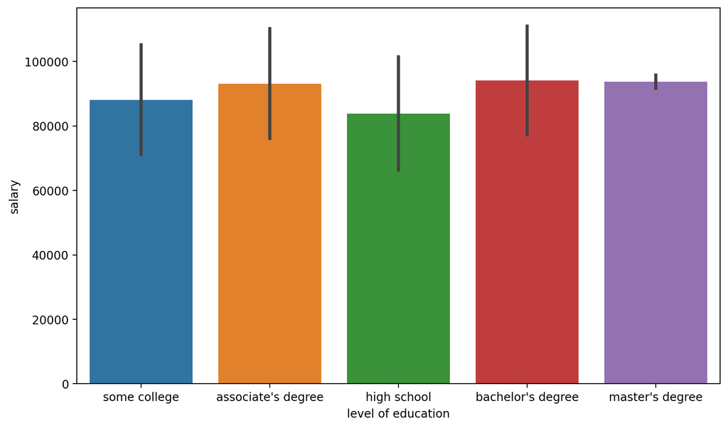

```python
plt.figure(figsize=(10,6),dpi=200)
# By default barplot() will show the mean
# Information on the black bar: https://stackoverflow.com/questions/58362473/what-does-black-lines-on-a-seaborn-barplot-mean
sns.barplot(x='level of education',y='salary',data=df,estimator=np.mean,ci='sd')
```

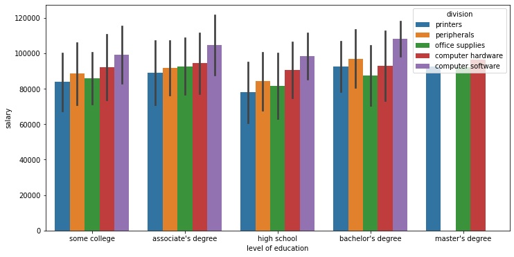

```python
plt.figure(figsize=(12,6))
sns.barplot(x='level of education',y='salary',data=df,estimator=np.mean,ci='sd',hue='division')
```

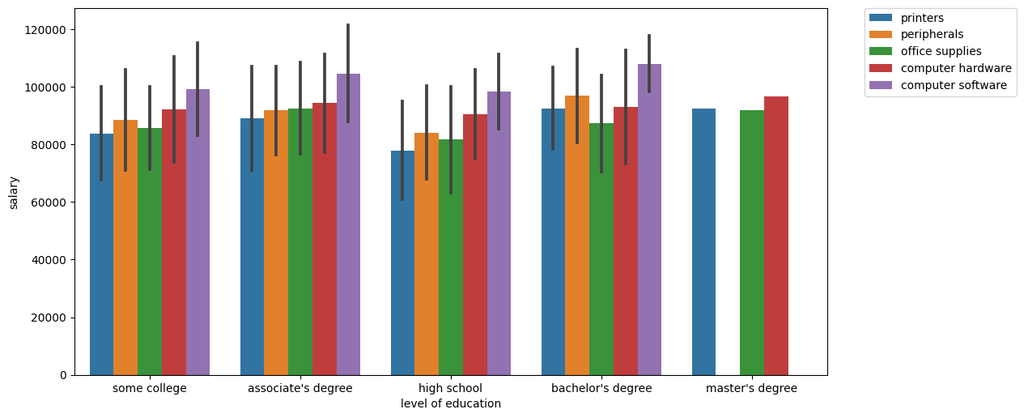

```python
plt.figure(figsize=(12,6),dpi=100)

# https://stackoverflow.com/questions/30490740/move-legend-outside-figure-in-seaborn-tsplot
sns.barplot(x='level of education',y='salary',data=df,estimator=np.mean,ci='sd',hue='division')

plt.legend(bbox_to_anchor=(1.05, 1))
```